# Wweek_5_Exploratory_Data_Analysis_Graphics_Labs

Nitie

9/21/2021

## R Markdown

```r
library(plotly)
library(ggplot2)
library(dplyr)
library(VennDiagram)
library(ggbeeswarm)
```

```r
#Read in dataset
```

```r
diab<-read.csv(file = "./data/diabetes2.csv",header = T, sep = ",")
```

2.EDA: Calculate summary statistics on diab and identify which variables seem to have invalid data in need of cleaning.

```r
str(diab)
```

```
## 'data.frame':    768 obs. of  9 variables:
##  $ preg : int  6 1 8 1 0 5 3 10 2 8 ...
##  $ plas : int  148 85 183 89 137 116 78 115 197 125 ...
##  $ pres : int  72 66 64 66 40 74 50 0 70 96 ...
##  $ skin : int  35 29 0 23 35 0 32 0 45 0 ...
##  $ insu : int  0 0 0 94 168 0 88 0 543 0 ...
##  $ mass : num  33.6 26.6 23.3 28.1 43.1 25.6 31 35.3 30.5 0 ...
##  $ pedi : num  0.627 0.351 0.672 0.167 2.288 ...
##  $ age  : int  50 31 32 21 33 30 26 29 53 54 ...
##  $ class: int  1 0 1 0 1 0 1 0 1 1 ...
```

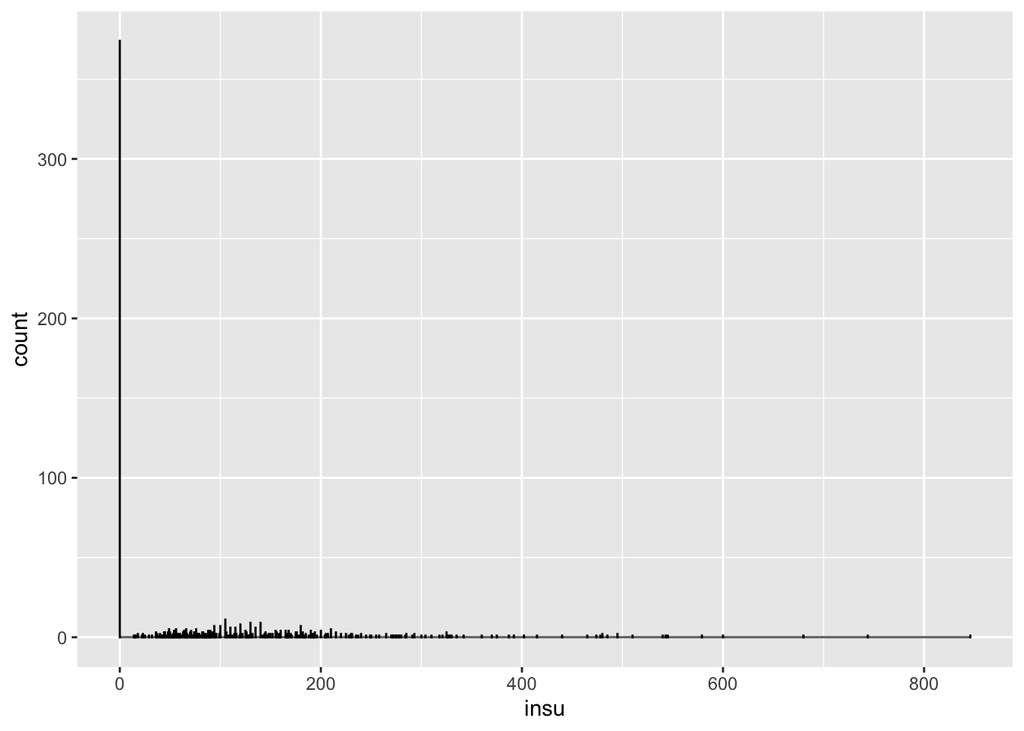

```r
freq_insu<- ggplot(diab, aes(insu)) + geom_histogram(color = "black", fill = "light blue", binwidth = 0.02)
freq_insu
```

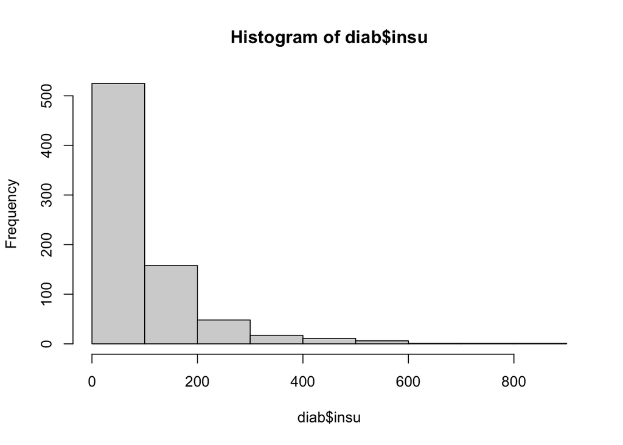

```r
hist(diab$insu)
```

```r
str(diab)
```

```
## 'data.frame':    768 obs. of  9 variables:
##  $ preg : int  6 1 8 1 0 5 3 10 2 8 ...
##  $ plas : int  148 85 183 89 137 116 78 115 197 125 ...
##  $ pres : int  72 66 64 66 40 74 50 0 70 96 ...
##  $ skin : int  35 29 0 23 35 0 32 0 45 0 ...
##  $ insu : int  0 0 0 94 168 0 88 0 543 0 ...
##  $ mass : num  33.6 26.6 23.3 28.1 43.1 25.6 31 35.3 30.5 0 ...
##  $ pedi : num  0.627 0.351 0.672 0.167 2.288 ...
##  $ age  : int  50 31 32 21 33 30 26 29 53 54 ...
##  $ class: int  1 0 1 0 1 0 1 0 1 1 ...
```

3. EDA: Plot the frequency distributions of all variables in diab and identify which variables seem to have invalid data in need of cleaning. Reconcile differences in #2 and #3, if there are any.

```r
table(diab$preg)
```

```
##
##   0   1   2   3   4   5   6   7   8   9  10  11  12  13  14  15  17
## 111 135 103  75  68  57  50  45  38  28  24  11   9  10   2   1   1
```

```r
table(diab$plas)
```

```
##
##   0  44  56  57  61  62  65  67  68  71  72  73  74  75  76  77  78  79  80  81
##   5   1   1   2   1   1   1   1   3   4   1   3   4   2   2   2   4   3   6   6
##  82  83  84  85  86  87  88  89  90  91  92  93  94  95  96  97  98  99 100 101
##   3   6  10   7   3   7   9   6  11   9   9   7   7  13   8   9   3  17  17   9
## 102 103 104 105 106 107 108 109 110 111 112 113 114 115 116 117 118 119 120 121
##  13   9   6  13  14  11  13  12   6  14  13   5  11  10   7  11   6  11  11   6
## 122 123 124 125 126 127 128 129 130 131 132 133 134 135 136 137 138 139 140 141
##  12   9  11  14   9   5  11  14   7   5   5   5   6   4   8   8   5   8   5   5
## 142 143 144 145 146 147 148 149 150 151 152 153 154 155 156 157 158 159 160 161
##   5   6   7   5   9   7   4   1   3   6   4   2   6   5   3   2   8   2   1   3
## 162 163 164 165 166 167 168 169 170 171 172 173 174 175 176 177 178 179 180 181
##   6   3   3   4   3   3   4   1   2   3   1   6   2   2   2   1   1   5   5   5
## 182 183 184 186 187 188 189 190 191 193 194 195 196 197 198 199
##   1   3   3   1   4   2   4   1   1   2   3   2   3   4   1   1
```

```r
table(diab$pres)
```

```
##
##   0  24  30  38  40  44  46  48  50  52  54  55  56  58  60  61  62  64  65  66
##  35   1   2   1   1   4   2   5  13  11  11   2  12  21  37   1  34  43   7  30
##  68  70  72  74  75  76  78  80  82  84  85  86  88  90  92  94  95  96  98 100
##  45  57  44  52   8  39  45  40  30  23   6  21  25  22   8   6   1   4   3   3
## 102 104 106 108 110 114 122
##   1   2   3   2   3   1   1
```

```r
table(diab$skin)
```

```
##
##   0   7   8  10  11  12  13  14  15  16  17  18  19  20  21  22  23  24  25  26
## 227   2   2   5   6   7  11   6  14   6  14  20  18  13  10  16  22  12  16  16
##  27  28  29  30  31  32  33  34  35  36  37  38  39  40  41  42  43  44  45  46
##  23  20  17  27  19  31  20   8  15  14  16   7  18  16  15  11   6   5   6   8
##  47  48  49  50  51  52  54  56  60  63  99
##   4   4   3   3   1   2   2   1   1   1   1
```

```r
table(diab$insu)
```

```
##
##   0  14  15  16  18  22  23  25  29  32  36  37  38  40  41  42  43  44  45  46
## 374   1   1   1   2   1   2   1   1   1   3   2   1   2   1   1   1   3   3   1
##  48  49  50  51  52  53  54  55  56  57  58  59  60  61  63  64  65  66  67  68
##   3   5   3   1   1   2   4   2   5   2   2   1   2   1   3   4   1   5   2   1
##  70  71  72  73  74  75  76  77  78  79  81  82  83  84  85  86  87  88  89  90
##   3   4   1   1   3   3   5   2   2   2   1   3   3   1   2   1   2   4   1   4
##  91  92  94  95  96  99 100 105 106 108 110 112 114 115 116 119 120 122 125 126
##   1   3   7   2   2   2   7  11   3   1   6   1   2   6   2   1   8   2   4   3
## 127 128 129 130 132 135 140 142 144 145 146 148 150 152 155 156 158 159 160 165
##   1   1   1   9   2   6   9   1   2   3   1   2   2   2   4   3   2   1   4   4
## 166 167 168 170 171 175 176 178 180 182 183 184 185 188 190 191 192 193 194 196
##   1   2   4   2   1   3   3   1   7   3   1   1   2   1   4   1   2   1   3   1
## 200 204 205 207 210 215 220 225 228 230 231 235 237 240 245 249 250 255 258 265
##   4   1   2   2   5   3   2   2   1   2   2   1   1   2   1   1   1   1   1   2
## 270 271 272 274 275 277 278 280 284 285 291 293 300 304 310 318 321 325 326 328
##   1   1   1   1   1   1   1   1   1   2   1   2   1   1   1   1   1   3   1   1
## 330 335 342 360 370 375 387 392 402 415 440 465 474 478 480 485 495 510 540 543
##   1   1   1   1   1   1   1   1   1   1   1   1   1   1   2   1   2   1   1   1
## 545 579 600 680 744 846
##   1   1   1   1   1   1
```

```r
table(diab$mass)
```

```
##
##    0 18.2 18.4 19.1 19.3 19.4 19.5 19.6 19.9   20 20.1 20.4 20.8   21 21.1 21.2
##   11    3    1    1    1    1    2    3    1    1    1    2    2    2    4    1
## 21.7 21.8 21.9 22.1 22.2 22.3 22.4 22.5 22.6 22.7 22.9   23 23.1 23.2 23.3 23.4
##    1    5    3    2    2    1    2    3    2    1    2    2    4    3    2    1
## 23.5 23.6 23.7 23.8 23.9   24 24.1 24.2 24.3 24.4 24.5 24.6 24.7 24.8 24.9   25
##    3    3    2    2    2    4    1    6    4    3    1    4    5    3    1    6
## 25.1 25.2 25.3 25.4 25.5 25.6 25.8 25.9   26 26.1 26.2 26.3 26.4 26.5 26.6 26.7
##    3    6    2    4    2    6    2    7    4    3    4    1    3    3    4    1
## 26.8 26.9   27 27.1 27.2 27.3 27.4 27.5 27.6 27.7 27.8 27.9   28 28.1 28.2 28.3
##    4    1    2    3    2    4    5    5    7    4    7    2    5    1    2    2
## 28.4 28.5 28.6 28.7 28.8 28.9   29 29.2 29.3 29.5 29.6 29.7 29.8 29.9   30 30.1
##    6    3    2    7    2    6    5    1    5    5    4    8    3    5    7    9
## 30.2 30.3 30.4 30.5 30.7 30.8 30.9   31 31.1 31.2 31.3 31.6 31.9   32 32.1 32.2
##    1    1    7    7    1    9    5    2    1   12    1   12    2   13    1    1
## 32.3 32.4 32.5 32.6 32.7 32.8 32.9 33.1 33.2 33.3 33.5 33.6 33.7 33.8 33.9   34
##    3   10    6    1    3    9    9    3    7   10    1    8    5    5    2    6
## 34.1 34.2 34.3 34.4 34.5 34.6 34.7 34.8 34.9   35 35.1 35.2 35.3 35.4 35.5 35.6
##    4    8    6    4    5    5    4    2    6    4    3    2    4    4    7    2
## 35.7 35.8 35.9   36 36.1 36.2 36.3 36.4 36.5 36.6 36.7 36.8 36.9   37 37.1 37.2
##    4    5    5    2    3    1    3    2    4    5    1    6    3    1    2    4
## 37.3 37.4 37.5 37.6 37.7 37.8 37.9   38 38.1 38.2 38.3 38.4 38.5 38.6 38.7 38.8
##    1    3    2    5    5    3    2    2    3    4    1    2    6    1    3    1
## 38.9   39 39.1 39.2 39.3 39.4 39.5 39.6 39.7 39.8 39.9   40 40.1 40.2 40.5 40.6
##    1    4    4    2    1    7    3    1    1    2    3    2    1    1    3    4
## 40.7 40.8 40.9   41 41.2 41.3 41.5 41.8   42 42.1 42.2 42.3 42.4 42.6 42.7 42.8
##    1    1    2    1    1    3    2    1    1    2    1    3    3    1    2    1
## 42.9 43.1 43.2 43.3 43.4 43.5 43.6   44 44.1 44.2 44.5 44.6   45 45.2 45.3 45.4
##    4    1    1    5    2    2    2    2    1    2    2    1    1    1    3    1
## 45.5 45.6 45.7 45.8 46.1 46.2 46.3 46.5 46.7 46.8 47.9 48.3 48.8 49.3 49.6 49.7
##    1    2    1    1    2    2    1    1    1    2    2    1    1    1    1    1
##   50 52.3 52.9 53.2   55 57.3 59.4 67.1
##    1    2    1    1    1    1    1    1
```

```r
table(diab$pedi)
```

```
##
## 0.078 0.084 0.085 0.088 0.089 0.092 0.096   0.1 0.101 0.102 0.107 0.108 0.115
##     1     1     2     2     1     1     1     1     1     1     1     1     1
## 0.118 0.121 0.122 0.123 0.126 0.127 0.128 0.129  0.13 0.133 0.134 0.135 0.136
##     1     2     1     1     2     2     2     2     1     1     2     1     1
## 0.137 0.138  0.14 0.141 0.142 0.143 0.144 0.145 0.147 0.148 0.149  0.15 0.151
##     2     1     2     3     3     2     1     1     1     3     1     2     3
## 0.153 0.154 0.155 0.156 0.157 0.158 0.159  0.16 0.161 0.162 0.163 0.164 0.165
##     2     1     1     1     1     2     2     1     2     1     1     2     3
## 0.166 0.167  0.17 0.171 0.173 0.174 0.175 0.176 0.177 0.178 0.179  0.18 0.181
##     1     4     1     1     1     1     1     1     1     3     1     2     1
## 0.182 0.183 0.186 0.187 0.188 0.189  0.19 0.191 0.192 0.194 0.196 0.197 0.198
##     1     2     1     3     1     2     4     2     2     1     1     4     2
## 0.199   0.2 0.201 0.203 0.204 0.205 0.206 0.207 0.209  0.21 0.212 0.215 0.217
##     1     3     1     2     2     3     2     5     2     1     2     1     1
## 0.218 0.219  0.22 0.221 0.222 0.223 0.225 0.226 0.227 0.229  0.23 0.231 0.232
##     2     2     1     1     1     2     1     1     1     1     2     2     1
## 0.233 0.234 0.235 0.236 0.237 0.238 0.239  0.24 0.241 0.243 0.244 0.245 0.246
##     2     2     3     3     4     5     1     2     1     1     2     4     1
## 0.247 0.248 0.249 0.251 0.252 0.253 0.254 0.255 0.256 0.257 0.258 0.259  0.26
##     2     2     2     2     2     1     6     1     3     3     6     5     4
## 0.261 0.262 0.263 0.264 0.265 0.267 0.268 0.269  0.27 0.271 0.272 0.277 0.278
##     5     2     4     1     1     2     5     2     4     1     1     1     2
## 0.279  0.28 0.282 0.283 0.284 0.285 0.286 0.287 0.289  0.29 0.292 0.293 0.294
##     1     3     2     1     4     2     2     1     2     2     3     2     3
## 0.295 0.296 0.297 0.299   0.3 0.302 0.303 0.304 0.305 0.306 0.307 0.313 0.314
##     1     1     1     4     1     2     1     4     3     2     1     2     2
## 0.315 0.317 0.318 0.319 0.323 0.324 0.325 0.326 0.328 0.329  0.33 0.331 0.332
##     2     1     1     1     2     2     1     2     2     1     1     1     1
## 0.334 0.335 0.336 0.337 0.338  0.34 0.341 0.342 0.343 0.344 0.345 0.346 0.347
##     2     1     2     3     1     3     1     2     2     2     1     1     1
## 0.349 0.351 0.352 0.355 0.356 0.358 0.361 0.362 0.364 0.365 0.366 0.368  0.37
##     3     1     1     1     2     1     2     1     2     2     1     2     2
## 0.371 0.374 0.375 0.376 0.378  0.38 0.381 0.382 0.383 0.385 0.388 0.389 0.391
##     1     1     1     1     2     2     1     1     1     1     1     3     3
## 0.393 0.394 0.395 0.396 0.398 0.399   0.4 0.401 0.402 0.403 0.404 0.407 0.408
##     1     1     1     1     1     1     2     1     2     2     1     2     1
## 0.409 0.411 0.412 0.415 0.416 0.417 0.419  0.42 0.421 0.422 0.423 0.426 0.427
##     1     1     2     2     1     1     1     1     1     3     1     1     1
##  0.43 0.431 0.432 0.433 0.434 0.435 0.439 0.441 0.443 0.444 0.446 0.447 0.451
```

[output cut: 26 more lines]

```
##     1     2     1     1     1     1     1     1     1     1     1     1     1
## 0.828 0.831 0.832 0.833 0.839  0.84 0.845 0.851 0.855 0.856 0.867 0.871 0.874
##     1     1     1     1     2     1     1     1     1     1     1     1     1
## 0.875 0.878  0.88 0.881 0.886 0.892 0.893 0.904 0.905 0.917 0.925 0.926  0.93
##     2     1     1     1     1     1     1     1     2     1     1     1     1
## 0.932 0.933 0.944 0.947 0.949 0.955 0.956 0.962 0.966 0.968  0.97 0.997 1.001
##     1     1     1     1     1     1     1     2     1     2     1     1     1
## 1.021 1.022 1.034 1.057 1.072 1.076 1.095 1.096 1.101 1.114 1.127 1.136 1.138
##     1     1     1     1     1     1     1     1     1     1     1     1     1
## 1.144 1.154 1.159 1.162 1.174 1.182 1.189 1.191 1.213 1.222 1.224 1.251 1.258
##     1     1     1     1     1     1     1     1     1     1     2     1     1
## 1.268 1.282 1.292 1.318 1.321 1.353  1.39 1.391 1.394   1.4 1.441 1.461 1.476
##     1     1     1     1     1     1     1     1     1     1     1     1     1
##   1.6 1.698 1.699 1.731 1.781 1.893 2.137 2.288 2.329  2.42
##     1     1     1     1     1     1     1     1     1     1
```

```r
table(diab$age)
```

```
##
## 21 22 23 24 25 26 27 28 29 30 31 32 33 34 35 36 37 38 39 40 41 42 43 44 45 46
## 63 72 38 46 48 33 32 35 29 21 24 16 17 14 10 16 19 16 12 13 22 18 13  8 15 13
## 47 48 49 50 51 52 53 54 55 56 57 58 59 60 61 62 63 64 65 66 67 68 69 70 72 81
##  6  5  5  8  8  8  5  6  4  3  5  7  3  5  2  4  4  1  3  4  3  1  2  1  1  1
```

```r
table(diab$class)
```

```
##
##   0   1
## 500 268
```

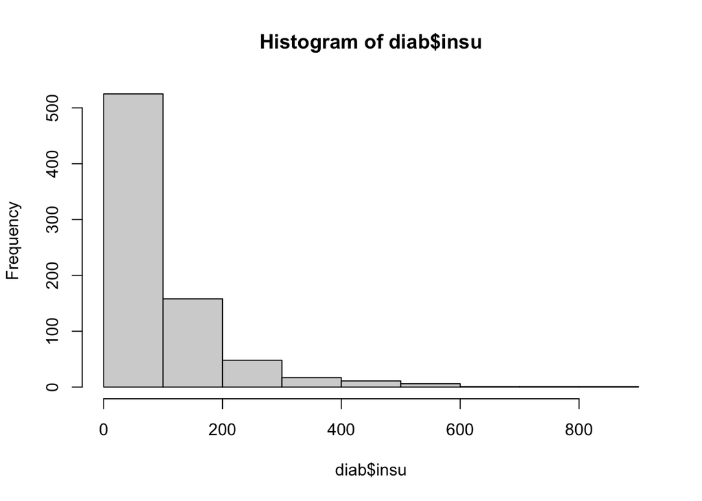

```r
hist(diab$insu)
```

4. For the variable insu produce a new variable of logical that has the value TRUE at any position in the vector diab$insu.

```r
diab$insu_0<-ifelse(diab$insu==0, TRUE,FALSE)
head(diab)
```

```
##   preg plas pres skin insu mass  pedi age class insu_0
## 1    6  148   72   35    0 33.6 0.627  50     1   TRUE
## 2    1   85   66   29    0 26.6 0.351  31     0   TRUE
## 3    8  183   64    0    0 23.3 0.672  32     1   TRUE
## 4    1   89   66   23   94 28.1 0.167  21     0  FALSE
## 5    0  137   40   35  168 43.1 2.288  33     1  FALSE
## 6    5  116   74    0    0 25.6 0.201  30     0   TRUE
```

```r
table(diab$insu_0)
```

```
##
## FALSE  TRUE
##   394   374
```

5a. For the variable pres (ie: blood pressure) produce a new variable of logical that has the value ZOMBIE at any position in the vector diab$pres where the blood pressure is that of a zombie rather than that of a human. Hint: zombies do not have a heartbeat – what BP results from no heartbeat?

```r
diab$pres_0<-ifelse(diab$pres==0, "ZOMBIE","HUMAN")
```

5b. For the variable pres use a logical expression from #4 to take a slice of the vector diab$pres. This slice will contain all the elements of diab$pres that need to be replaced with NA.

```r
slice_pres0<-diab$skin[diab$pres==0]
length(slice_pres0)
```

```
## [1] 35
```

6. For the variable pres use your slice of diab$pres from #5 to replace the values that should be NA with the value NA. Hint: one way is to use something like this, filling in with your logical expression from #4 and #5: diab$pres[] <- NA

```r
diab$pres[diab$pres==0]<-"NA"
```

7. For the variable skin (ie: measure of skin fold thickness at triceps) use a logical expression to take a slice of the vector diab$skin. This slice will contain all the elements of diab$skin that need to be replaced with NA.

Hint: the slice will contain all values of diab$skin where the skin fold thickness is that of a skeleton rather than that of a human. (Skeletons have zero skin thickness).

```r
slice_skin<-diab$skin[diab$skin==0]
```

8. For the variable skin use your slice of diab$skin from #7 to replace the values that should be NA with the value NA.

```r
diab$skin[diab$skin==0]<-"NA"
```

9. Confirm that variable insu needs cleaning, clean them by replacing values that should be NA, with values within normal range (16 -180 mu U/ml).

```r
diab$insu[diab$insu<16]<-"NA"
diab$insu[diab$insu>=180]<-"NA"
```

10. For all the variables other than pres and skin that need cleaning, clean them by replacing values that should be NA, with values between the 1st interquatile and mean of the variable.

```r
summary(diab)
```

```
##       preg             plas           pres               skin
##  Min.   : 0.000   Min.   :  0.0   Length:768         Length:768
##  1st Qu.: 1.000   1st Qu.: 99.0   Class :character   Class :character
##  Median : 3.000   Median :117.0   Mode  :character   Mode  :character
##  Mean   : 3.845   Mean   :120.9
##  3rd Qu.: 6.000   3rd Qu.:140.2
##  Max.   :17.000   Max.   :199.0
##      insu                mass            pedi             age
##  Length:768         Min.   : 0.00   Min.   :0.0780   Min.   :21.00
##  Class :character   1st Qu.:27.30   1st Qu.:0.2437   1st Qu.:24.00
##  Mode  :character   Median :32.00   Median :0.3725   Median :29.00
##                     Mean   :31.99   Mean   :0.4719   Mean   :33.24
##                     3rd Qu.:36.60   3rd Qu.:0.6262   3rd Qu.:41.00
##                     Max.   :67.10   Max.   :2.4200   Max.   :81.00
##      class         insu_0           pres_0
##  Min.   :0.000   Mode :logical   Length:768
##  1st Qu.:0.000   FALSE:394       Class :character
##  Median :0.000   TRUE :374       Mode  :character
##  Mean   :0.349
##  3rd Qu.:1.000
##  Max.   :1.000
```

```r
diab$preg[diab$preg<=1]<-"NA"
diab$preg[diab$preg>=3]<-"NA"

diab$plas[diab$plas<=99]<-"NA"
diab$plas[diab$plas>=117]<-"NA"

diab$insu[diab$insu==0]<-"NA"
diab$insu[diab$insu>=30]<-"NA"

diab$mass[diab$mass<=27]<-"NA"
diab$mass[diab$mass>=31.99]<-"NA"

diab$pedi[diab$pedi<=0.2437]<-"NA"
diab$pedi[diab$pedi>=0.3725]<-"NA"

diab$age[diab$age>=24]<-"NA"
diab$age[diab$age<=29]<-"NA"

#diab$class[diab$class<=0]<-"NA"
#diab$class[diab$class>=0.349]<-"NA"
```

11. Execute the following commands, each one on a different column of diab: summary, range, IQR, quantile, median, mean Very briefly describe what the commands reveal

```r
summary(diab)
```

```
##      preg               plas               pres               skin
##  Length:768         Length:768         Length:768         Length:768
##  Class :character   Class :character   Class :character   Class :character
##  Mode  :character   Mode  :character   Mode  :character   Mode  :character
##
##
##
##      insu               mass               pedi               age
##  Length:768         Length:768         Length:768         Length:768
##  Class :character   Class :character   Class :character   Class :character
##  Mode  :character   Mode  :character   Mode  :character   Mode  :character
##
##
##
##      class         insu_0           pres_0
##  Min.   :0.000   Mode :logical   Length:768
##  1st Qu.:0.000   FALSE:394       Class :character
##  Median :0.000   TRUE :374       Mode  :character
##  Mean   :0.349
##  3rd Qu.:1.000
##  Max.   :1.000
```

12. Create the grouped histogram for • class variable of diab. Include a title, x and y labels in your plot.

```r
class(diab$class)
```

```
## [1] "integer"
```

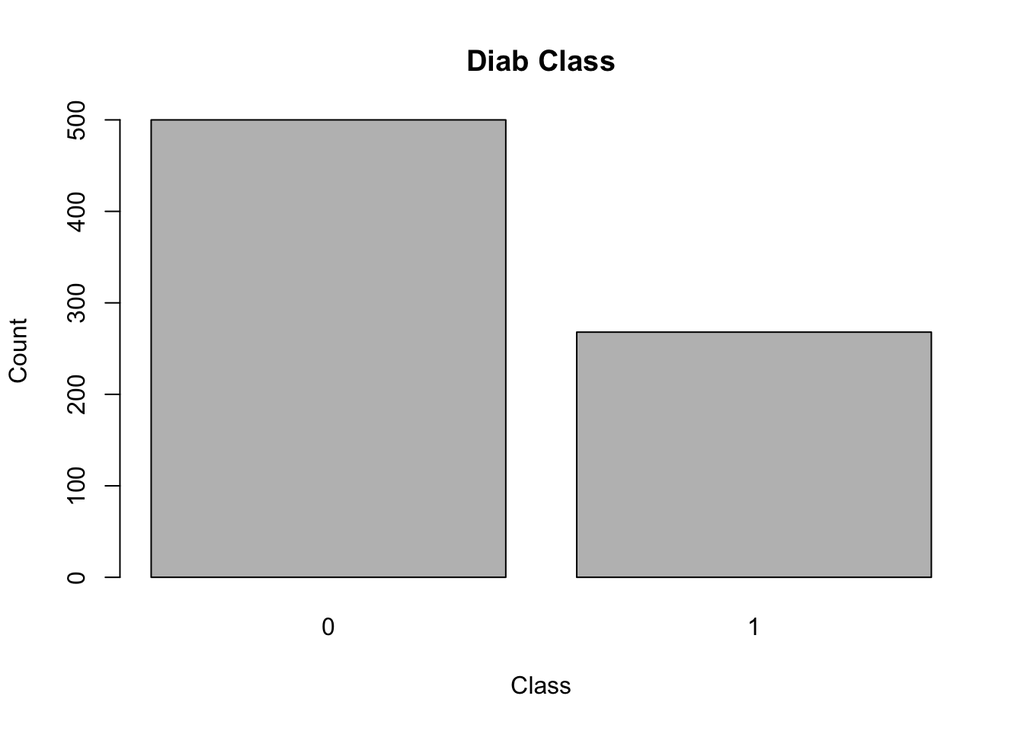

```r
diab$class<-as.factor(diab$class)

count<-table(diab$class)

barplot(count, main = "Diab Class", xlab = "Class", ylab = "Count", name.arg=c("0","1"))
```

13. As in #12, plot the class variable of diab, but first typecast (coerce) the class variable to type factor. Include title and axis labels as before.

```r
class(diab$class)
```

```
## [1] "factor"
```

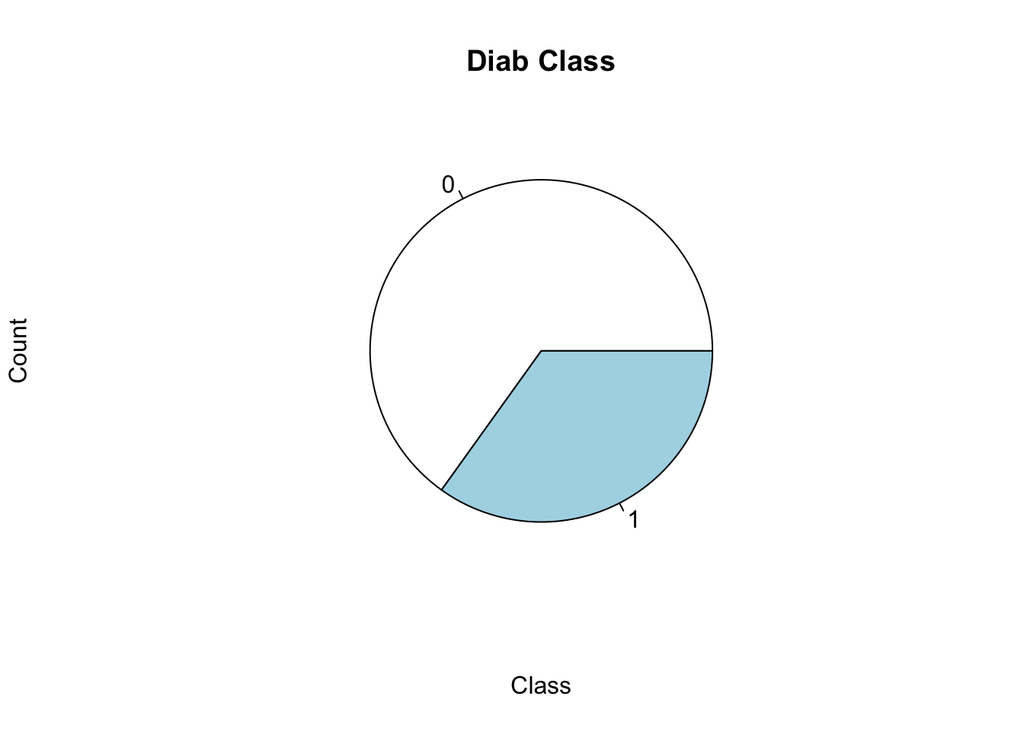

```r
diab$class<-as.factor(diab$class)

pie(count, main = "Diab Class", xlab = "Class", ylab = "Count", name.arg=c("0","1"))
```

14. Create a plot of your own choosing to show the distribution of a single variable OR the relation between 2 variables of the diab dataset. Include a title and axis labels in your plot.

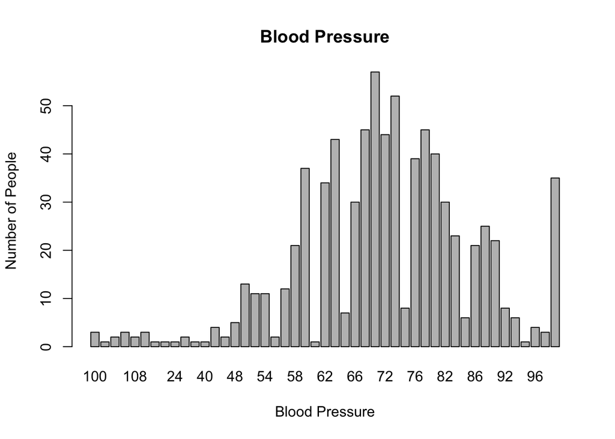

```r
count_2<-(diab$pres)
barplot(table(count_2), xlab="Blood Pressure", ylab ="Number of People", main = "Blood Pressure")
```

15. Note: this question is meant to be strange; figure out what is going on: Execute the following 2 lines of code: diab$col1 <-diab$pres/(diab$pres-median(diab$pres, na.rm=T) ) diab$col2 <- sqrt(diab$pres/(diab$pres-median(diab$pres, na.rm=T) ) )

Then execute the two which commands below:

which is introduced in Book of R ch 4, the other functions in ch 6 which(is.infinite(diab$col1)) which(is.nan(diab$col2))

After executing these, explain what happened in the creation of col1 and col2 to result in the output of each of the two calls to which

```r
#is.finite() function is used to check if the elements of a vector are Finite values or not. It returns a boolean value for all the elements of the vector.

#When execute is.nan, it gave a larger group of vectors. It is used to check if the vector contains any non number value as element. It returns a boolean value for all the elements of the vector.
```

[output not shown]

[output not shown]